# Unsupervised Learning : Uncovering Underlying Constructs of Chronic Disease Indicators Across US States Using Exploratory and Confirmatory Factor Analyses

John Pauline Pineda

November 5, 2023

# **1. Table of Contents**

## 1.1 Introduction

Chronic disease indicators (CDI) are a set of surveillance indicators developed by consensus among the [Center for Disease Controls and Prevention (CDC)](https://www.cdc.gov/), [Council of State and Territorial Epidemiologists (CSTE)](https://www.cste.org/), and [National Association of Chronic Disease Directors (NACDD)](https://chronicdisease.org/). [CDI enables public health professionals and policymakers to retrieve uniformly defined state-level data for chronic diseases and risk factors](https://www.cdc.gov/cdi/overview.html) that have a substantial impact on public health. These indicators are essential for surveillance, prioritization, and evaluation of public health interventions.  
Using an open dataset from [Data.World](https://data.world/) as primarily sourced from [CDC](https://www.cdc.gov/cdi/index.html), this study hypothesized that latent patterns are present among sufficiently correlated [indicators](https://datatopics.worldbank.org/world-development-indicators/) encompassing multiple chronic disease topic areas in the US. A number of factor analysis models was formulated to explore and verify the relationship between these factors.  
Subsequent analysis and modelling steps involving data understanding, data preparation, data exploration, model development, model validation and model presentation were individually detailed below, with all the results consolidated in a **Summary** provided at the end of the document.

### 1.1.1 Study Objectives

**The main objective of the study is to explore and validate potential underlying factor structures and relationships among a set of observed US chronic disease indicators by identifying latent factors that explain the observed correlations and reducing the complexity of the data by grouping related indicators together under these discovered factors.**  
Specific objectives are given as follows:  
**[A]** Obtain an optimal subset of observations and descriptors by conducting data quality assessment and applying preprocessing operations most suitable for the downstream analysis  
**[B]** Develop exploratory factor analysis models using various extraction methods to estimate and identify potential underlying structures from observed descriptors and different rotation approaches in simplifying the derived factor structures to achieve a more interpretable pattern of factor loadings  
**[C]** Select the final exploratory factor analysis model among candidates based on robust performance estimates  
**[D]** Validate the relationship obtained from the final exploratory analysis model between the observed descriptors and their underlying latent constructs using confirmatory factor analysis

### 1.1.2 Outcome

There is no explicit endpoint for the study given the unsupervised learning nature of the analysis.

### 1.1.3 Descriptors

Detailed information for each individual descriptor used in the study are provided as follows:  
**[A]** LDMORT (numeric): **Liver Disease Mortality**; Chronic liver disease mortality.  
**[B]** ARTINC (numeric): **Arthritis Incidence**; Arthritis among adults aged >= 18 years.  
**[C]** ASMORT (numeric): **Asthma Mortality**; Asthma mortality rate.  
**[D]** PSMUSE (numeric): **Papanicolaou Smear Use**; Papanicolaou smear use among adult women aged 21-65 years.  
**[E]** RDMORT (numeric): **Renal Disease Mortality**; Mortality with end-stage renal disease.  
**[F]** PDMORT (numeric): **Pulmonary Disease Mortality**; Mortality with chronic obstructive pulmonary disease as underlying cause among adults aged >=45 years.  
**[G]** CDMORT (numeric): **Cardiovascular Disease Mortality**; Mortality from total cardiovascular disease.  
**[H]** HDMORT (numeric): **Heart Disease Mortality**; Mortality from diseases of the heart.  
**[I]** STMORT (numeric): **Stroke Mortality**; Mortality from stroke.  
**[J]** DBMORT (numeric): **Diabetes Mortality**; Mortality due to diabetes reported as any listed cause of death.  
**[K]** INFVAC (numeric): **Influenza Vaccination**; Influenza vaccination among noninstitutionalized adults aged >= 18 years.  
**[L]** MEUNDA (numeric): **Mentally Unhealthy Days**; Recent mentally unhealthy days among adults aged >= 18 years.  
**[M]** OVWINC (numeric): **Overweight Incidence**; Overweight or obesity among adults aged >= 18 years.  
**[N]** HLTINS (numeric): **Health Insurance**; Current lack of health insurance among adults aged 18-64 years.  
**[O]** SMPREV (numeric): **Smoking Prevalence**; Current smoking among adults aged >= 18 years.

## 1.2 Methodology

### 1.2.1 Data Assessment

Preliminary data used in the study was evaluated and prepared for analysis and modelling using the following methods:  
[Covariance Validity](https://www.pearson.com/en-us/subject-catalog/p/using-multivariate-statistics/P200000003097/9780137526543) evaluates whether the ratio of associated variables in the data set are sufficient enough to support the assumption that correlations exist. The criterion is computed by determining the proportion of correlation coefficients with values of at least 30% between all pairs of variables in the data set. A value closer to 1 suggests an adequate percentage of pairwise-correlated variables.  
[Determinant Computation](https://www.taylorfrancis.com/books/mono/10.4324/9781003120001/step-step-guide-exploratory-factor-analysis-rstudio-marley-watkins) reflects the extent of multicollinearity among the variables in a correlation matrix. An extremely small determinant value indicates that the variables are highly correlated and nearly linearly dependent which can lead to unstable results and difficulty in interpreting their individual contributions.  
[Bartlett’s Test of Sphericity](https://www.semanticscholar.org/paper/THE-EFFECT-OF-STANDARDIZATION-ON-A-%CF%872-APPROXIMATION-Bartlett/95d549d2c055360b34cc7d1fce739179c29e39bb) evaluates whether the correlations between variables in a data set are significant enough to support the assumption that underlying factors exist and can be extracted. The test calculates a Chi-Square statistic based on the differences between the observed correlation matrix and an identity matrix. The larger the Chi-Square value, there is more evidence against the null hypothesis stating that the correlation matrix is an identity matrix which indicates that the variables are uncorrelated and do not have any underlying structure.  
[Kaiser-Meyer-Olkin Factor Adequacy](https://link.springer.com/article/10.1007/BF02291817) evaluates whether the observed variables are suitable for exploratory factor analysis based on their common variance and the potential for extracting meaningful factors. The criterion is computed by examining the ratio of the sum of squared correlations between variables to the sum of squared partial correlations. A KMO value closer to 1 suggests that the variables have high shared variance and are suitable to proceed with the analysis.

### 1.2.2 Model Formulation

[Principal Axes Factor Extraction](https://www.pearson.com/en-us/subject-catalog/p/using-multivariate-statistics/P200000003097/9780137526543) identifies the underlying constructs that explain the observed correlations among variables by capturing both common variance (shared among variables) and unique variance (specific to each variable). This process potentially results to factors with lower communalities (explained variance) but with more direct interpretability. The algorithm performs eigenvalue decomposition on the correlation matrix. The eigenvalues represent the amount of variance explained by each eigenvector. Given a defined number of factors, loadings are calculated for each observed variable on each extracted factor. Factor loadings indicate the strength and direction of the relationship between variables and factors. Factors are interpreted based on the loading patterns. Variables with high loadings on a factor are strongly associated with the factor.  
[Maximum Likelihood Factor Extraction](https://www.pearson.com/en-us/subject-catalog/p/using-multivariate-statistics/P200000003097/9780137526543) aims to estimate the factor loadings in a way that maximizes the likelihood of observing the given data, assuming a specific factor model. Given the correlation matrix, the algorithm formulates a likelihood function that represents the probability of observing the given data under an assumed factor model representing the relationships between the latent factors and observed variables. The likelihood function quantifies how well the model explains the observed data. Optimization techniques are applied to determine the factor loadings that maximize the likelihood function. The process involves iteratively adjusting the factor loadings to improve the fit between the model and the data. Factor loadings indicate the strength and direction of the relationship between variables and factors. Factors are interpreted based on the loading patterns. Variables with high loadings on a factor are strongly associated with the factor.  
[Varimax Rotation](https://www.pearson.com/en-us/subject-catalog/p/using-multivariate-statistics/P200000003097/9780137526543) is an orthogonal rotation method which forces the rotated factors to be uncorrelated with each other, leading to simpler and more easily interpretable factor solutions. The algorithm aims to maximize the variance of the squared loadings within each factor which helps identify variables that are strongly associated with a single factor. The results are straightforward to interpret and can be particularly useful when the factors are expected to be independent.  
[Promax Rotation](https://www.pearson.com/en-us/subject-catalog/p/using-multivariate-statistics/P200000003097/9780137526543) is an oblique rotation method which allows for more flexibility by accommodating the possibility of correlated factors. The algorithm aims to simplify the factor structure by both maximizing the variance of the squared loadings within each factor and allowing for correlated factors. It uses a more complex mathematical approach to find the optimal rotation that accounts for both variance and correlation. The results provide a more accurate representation of the underlying relationships when the factors are expected to be correlated.

## 1.3 Results

### 1.3.1 Data Preparation

**Code Chunk | Output**

```r
##################################
# Loading R libraries
##################################
library(AppliedPredictiveModeling)
library(performance)
library(parameters)
library(HH)
library(tidyr)
library(caret)
library(psych)
library(lattice)
library(dplyr)
library(moments)
library(skimr)
library(RANN)
library(pls)
library(corrplot)
library(lares)
library(DMwR)
library(gridExtra)
library(rattle)
library(RColorBrewer)
library(stats)
library(factoextra)
library(FactoMineR)
library(gplots)
library(qgraph)
library(ggplot2)
library(psych)
library(nFactors)
library(MBESS)
library(mice)
library(DandEFA)
library(EFAtools)
library(tidyverse)
library(lavaan)
library(semPlot)
library(semoutput)
library(sjPlot)
library(GPArotation)
library(semTools)

##################################
# Loading source and
# formulating the analysis set
##################################
CDI <- read.csv("ChronicDiseaseIndicators.csv",
                      na.strings=c("NA","NaN"," ",""),
                      stringsAsFactors = FALSE)
CDI <- as.data.frame(CDI)

##################################
# Performing a general exploration of the data set
##################################
dim(CDI)
```

```
## [1] 50 16
```

```r
str(CDI)
```

```
## 'data.frame':    50 obs. of  16 variables:
##  $ STATE : chr  "Alabama" "Alaska" "Arizona" "Arkansas" ...
##  $ LDMORT: num  11.8 10.7 14.3 10.4 12 12.7 8.5 9.3 11.8 8.6 ...
##  $ ARTINC: num  31.7 22.5 23.2 28.1 19.9 22.1 21.4 23.8 23.1 24.6 ...
##  $ ASMORT: num  10.7 NA 11.7 11 10 7.8 8.7 NA 8.6 9.9 ...
##  $ PSMUSE: num  83 78.5 79.8 77.8 83.7 84.8 87.6 86.8 79.9 84.5 ...
##  $ RDMORT: num  60.1 49.2 37.3 65.8 51 44.2 47.7 58.7 39.1 55.1 ...
##  $ PDMORT: num  148.3 105.7 116.5 163 87.8 ...
##  $ CDMORT: num  292 193 183 279 194 ...
##  $ HDMORT: num  224 147 136 218 142 ...
##  $ STMORT: num  48.3 32.3 28.3 45.4 33.9 33.4 26.3 38.8 33 42.6 ...
##  $ DBMORT: num  59.5 59.3 55.1 71.6 69.9 52 43.8 57.2 49.3 55.2 ...
##  $ INFVAC: num  37.7 35 32.6 39.6 35.7 44.2 41.3 39.4 29 34.1 ...
##  $ MEUNDA: num  4.7 3 3.7 4.4 3.6 3.2 3.7 3.6 3.8 4 ...
##  $ OVWINC: num  66.9 65.2 64 70.7 59.8 57.2 59.6 67.3 61.5 65.7 ...
##  $ HLTINS: num  17.9 17.1 18.1 20.3 17.8 15.5 11 11.2 23.1 25.2 ...
##  $ SMPREV: num  21.7 19.5 16.9 25.4 12.8 15.8 16.1 20.3 18.6 17.4 ...
```

```r
summary(CDI)
```

```
##     STATE               LDMORT          ARTINC          ASMORT
##  Length:50          Min.   : 6.80   Min.   :19.00   Min.   : 7.50
##  Class :character   1st Qu.: 8.70   1st Qu.:23.12   1st Qu.: 9.45
##  Mode  :character   Median :10.20   Median :24.15   Median :11.00
##                     Mean   :10.54   Mean   :24.78   Mean   :11.32
##                     3rd Qu.:11.95   3rd Qu.:25.98   3rd Qu.:13.30
##                     Max.   :22.50   Max.   :35.90   Max.   :16.70
##                                                     NA's   :11
##      PSMUSE          RDMORT          PDMORT          CDMORT
##  Min.   :76.20   Min.   :37.30   Min.   : 43.9   Min.   :164.7
##  1st Qu.:80.53   1st Qu.:49.30   1st Qu.:102.3   1st Qu.:195.2
##  Median :82.70   Median :54.90   Median :119.8   Median :208.8
##  Mean   :82.59   Mean   :55.54   Mean   :120.0   Mean   :220.0
##  3rd Qu.:85.33   3rd Qu.:59.98   3rd Qu.:139.6   3rd Qu.:242.1
##  Max.   :87.90   Max.   :78.50   Max.   :177.7   Max.   :300.5
##
##      HDMORT          STMORT          DBMORT           INFVAC
##  Min.   :116.5   Min.   :25.60   Min.   : 42.30   Min.   :29.00
##  1st Qu.:147.8   1st Qu.:33.50   1st Qu.: 57.05   1st Qu.:35.88
##  Median :158.1   Median :36.75   Median : 64.85   Median :39.20
##  Mean   :167.0   Mean   :36.86   Mean   : 67.37   Mean   :39.01
##  3rd Qu.:182.3   3rd Qu.:41.45   3rd Qu.: 75.55   3rd Qu.:42.02
##  Max.   :229.9   Max.   :48.80   Max.   :117.20   Max.   :49.00
##
##      MEUNDA          OVWINC          HLTINS          SMPREV
##  Min.   :2.800   Min.   :57.20   Min.   : 5.40   Min.   : 9.50
##  1st Qu.:3.325   1st Qu.:62.60   1st Qu.:12.55   1st Qu.:16.62
##  Median :3.700   Median :65.10   Median :15.70   Median :18.90
##  Mean   :3.686   Mean   :64.54   Mean   :15.84   Mean   :19.02
##  3rd Qu.:4.000   3rd Qu.:66.75   3rd Qu.:18.32   3rd Qu.:21.25
##  Max.   :4.900   Max.   :70.80   Max.   :29.10   Max.   :28.20
##
```

```r
##################################
# Formulating a data type assessment summary
##################################
PDA <- CDI
(PDA.Summary <- data.frame(
  Column.Index=c(1:length(names(PDA))),
  Column.Name= names(PDA),
  Column.Type=sapply(PDA, function(x) class(x)),
  row.names=NULL)
)
```

```
##    Column.Index Column.Name Column.Type
## 1             1       STATE   character
## 2             2      LDMORT     numeric
## 3             3      ARTINC     numeric
## 4             4      ASMORT     numeric
## 5             5      PSMUSE     numeric
## 6             6      RDMORT     numeric
## 7             7      PDMORT     numeric
## 8             8      CDMORT     numeric
## 9             9      HDMORT     numeric
## 10           10      STMORT     numeric
## 11           11      DBMORT     numeric
## 12           12      INFVAC     numeric
## 13           13      MEUNDA     numeric
## 14           14      OVWINC     numeric
## 15           15      HLTINS     numeric
## 16           16      SMPREV     numeric
```

### 1.3.2 Data Quality Assessment

**[A]** Missing data noted for 1 variable with Null.Count>0 and Fill.Rate<1.0.  
**[A.1]** ASMORT: Null.Count=11, Fill.Rate=0.78  
**[B]** No low variance observed for any variable with First.Second.Mode.Ratio>5.  
**[C]** No low variance observed for any variable with Unique.Count.Ratio<0.01.  
**[D]** No high skewness observed for any variable with Skewness>3 or Skewness<(-3).

**Code Chunk | Output**

```r
##################################
# Loading dataset
##################################
DQA <- CDI

##################################
# Formulating an overall data quality assessment summary
##################################
(DQA.Summary <- data.frame(
  Column.Name= names(DQA),
  Column.Type=sapply(DQA, function(x) class(x)),
  Row.Count=sapply(DQA, function(x) nrow(DQA)),
  NA.Count=sapply(DQA,function(x)sum(is.na(x))),
  Fill.Rate=sapply(DQA,function(x)format(round((sum(!is.na(x))/nrow(DQA)),3),nsmall=3)),
  row.names=NULL)
)
```

```
##    Column.Name Column.Type Row.Count NA.Count Fill.Rate
## 1        STATE   character        50        0     1.000
## 2       LDMORT     numeric        50        0     1.000
## 3       ARTINC     numeric        50        0     1.000
## 4       ASMORT     numeric        50       11     0.780
## 5       PSMUSE     numeric        50        0     1.000
## 6       RDMORT     numeric        50        0     1.000
## 7       PDMORT     numeric        50        0     1.000
## 8       CDMORT     numeric        50        0     1.000
## 9       HDMORT     numeric        50        0     1.000
## 10      STMORT     numeric        50        0     1.000
## 11      DBMORT     numeric        50        0     1.000
## 12      INFVAC     numeric        50        0     1.000
## 13      MEUNDA     numeric        50        0     1.000
## 14      OVWINC     numeric        50        0     1.000
## 15      HLTINS     numeric        50        0     1.000
## 16      SMPREV     numeric        50        0     1.000
```

```r
##################################
# Listing all descriptors
##################################
DQA.Descriptors <- DQA[,colnames(DQA)!="State"]

##################################
# Listing all numeric Descriptors
##################################
DQA.Descriptors.Numeric <- DQA.Descriptors[,sapply(DQA.Descriptors, is.numeric)]

if (length(names(DQA.Descriptors.Numeric))>0) {
    print(paste0("There are ",
               (length(names(DQA.Descriptors.Numeric))),
               " numeric descriptor variable(s)."))
} else {
  print("There are no numeric descriptor variables.")
}
```

```
## [1] "There are 15 numeric descriptor variable(s)."
```

```r
##################################
# Listing all factor Descriptors
##################################
DQA.Descriptors.Factor <- DQA.Descriptors[,sapply(DQA.Descriptors, is.factor)]

if (length(names(DQA.Descriptors.Factor))>0) {
    print(paste0("There are ",
               (length(names(DQA.Descriptors.Factor))),
               " factor descriptor variable(s)."))
} else {
  print("There are no factor descriptor variables.")
}
```

```
## [1] "There are no factor descriptor variables."
```

```r
##################################
# Formulating a data quality assessment summary for factor Descriptors
##################################
if (length(names(DQA.Descriptors.Factor))>0) {

  ##################################
  # Formulating a function to determine the first mode
  ##################################
  FirstModes <- function(x) {
    ux <- unique(na.omit(x))
    tab <- tabulate(match(x, ux))
    ux[tab == max(tab)]
  }

  ##################################
  # Formulating a function to determine the second mode
  ##################################
  SecondModes <- function(x) {
    ux <- unique(na.omit(x))
    tab <- tabulate(match(x, ux))
    fm = ux[tab == max(tab)]
    sm = x[!(x %in% fm)]
    usm <- unique(sm)
    tabsm <- tabulate(match(sm, usm))
    ifelse(is.na(usm[tabsm == max(tabsm)])==TRUE,
           return("x"),
           return(usm[tabsm == max(tabsm)]))
  }

  (DQA.Descriptors.Factor.Summary <- data.frame(
  Column.Name= names(DQA.Descriptors.Factor),
  Column.Type=sapply(DQA.Descriptors.Factor, function(x) class(x)),
  Unique.Count=sapply(DQA.Descriptors.Factor, function(x) length(unique(x))),
  First.Mode.Value=sapply(DQA.Descriptors.Factor, function(x) as.character(FirstModes(x)[1])),
  Second.Mode.Value=sapply(DQA.Descriptors.Factor, function(x) as.character(SecondModes(x)[1])),
  First.Mode.Count=sapply(DQA.Descriptors.Factor, function(x) sum(na.omit(x) == FirstModes(x)[1])),
  Second.Mode.Count=sapply(DQA.Descriptors.Factor, function(x) sum(na.omit(x) == SecondModes(x)[1])),
  Unique.Count.Ratio=sapply(DQA.Descriptors.Factor, function(x) format(round((length(unique(x))/nrow(DQA.Descriptors.Factor)),3), nsmall=3)),
  First.Second.Mode.Ratio=sapply(DQA.Descriptors.Factor, function(x) format(round((sum(na.omit(x) == FirstModes(x)[1])/sum(na.omit(x) == SecondModes(x)[1])),3), nsmall=3)),
  row.names=NULL)
  )

}

##################################
# Formulating a data quality assessment summary for numeric Descriptors
##################################
if (length(names(DQA.Descriptors.Numeric))>0) {

  ##################################
  # Formulating a function to determine the first mode
  ##################################
  FirstModes <- function(x) {
    ux <- unique(na.omit(x))
    tab <- tabulate(match(x, ux))
    ux[tab == max(tab)]
  }

  ##################################
  # Formulating a function to determine the second mode
  ##################################
  SecondModes <- function(x) {
    ux <- unique(na.omit(x))
    tab <- tabulate(match(x, ux))
    fm = ux[tab == max(tab)]
    sm = na.omit(x)[!(na.omit(x) %in% fm)]
    usm <- unique(sm)
    tabsm <- tabulate(match(sm, usm))
    ifelse(is.na(usm[tabsm == max(tabsm)])==TRUE,
           return(0.00001),
           return(usm[tabsm == max(tabsm)]))
  }

  (DQA.Descriptors.Numeric.Summary <- data.frame(
  Column.Name= names(DQA.Descriptors.Numeric),
  Column.Type=sapply(DQA.Descriptors.Numeric, function(x) class(x)),
  Unique.Count=sapply(DQA.Descriptors.Numeric, function(x) length(unique(x))),
  Unique.Count.Ratio=sapply(DQA.Descriptors.Numeric, function(x) format(round((length(unique(x))/nrow(DQA.Descriptors.Numeric)),3), nsmall=3)),
  First.Mode.Value=sapply(DQA.Descriptors.Numeric, function(x) format(round((FirstModes(x)[1]),3),nsmall=3)),
  Second.Mode.Value=sapply(DQA.Descriptors.Numeric, function(x) format(round((SecondModes(x)[1]),3),nsmall=3)),
  First.Mode.Count=sapply(DQA.Descriptors.Numeric, function(x) sum(na.omit(x) == FirstModes(x)[1])),
  Second.Mode.Count=sapply(DQA.Descriptors.Numeric, function(x) sum(na.omit(x) == SecondModes(x)[1])),
  First.Second.Mode.Ratio=sapply(DQA.Descriptors.Numeric, function(x) format(round((sum(na.omit(x) == FirstModes(x)[1])/sum(na.omit(x) == SecondModes(x)[1])),3), nsmall=3)),
  Minimum=sapply(DQA.Descriptors.Numeric, function(x) format(round(min(x,na.rm = TRUE),3), nsmall=3)),
  Mean=sapply(DQA.Descriptors.Numeric, function(x) format(round(mean(x,na.rm = TRUE),3), nsmall=3)),
  Median=sapply(DQA.Descriptors.Numeric, function(x) format(round(median(x,na.rm = TRUE),3), nsmall=3)),
  Maximum=sapply(DQA.Descriptors.Numeric, function(x) format(round(max(x,na.rm = TRUE),3), nsmall=3)),
  Skewness=sapply(DQA.Descriptors.Numeric, function(x) format(round(skewness(x,na.rm = TRUE),3), nsmall=3)),
  Kurtosis=sapply(DQA.Descriptors.Numeric, function(x) format(round(moments::kurtosis(x,na.rm = TRUE),3), nsmall=3)),
  Percentile25th=sapply(DQA.Descriptors.Numeric, function(x) format(round(quantile(x,probs=0.25,na.rm = TRUE),3), nsmall=3)),
  Percentile75th=sapply(DQA.Descriptors.Numeric, function(x) format(round(quantile(x,probs=0.75,na.rm = TRUE),3), nsmall=3)),
  row.names=NULL)
  )

}
```

```
##    Column.Name Column.Type Unique.Count Unique.Count.Ratio First.Mode.Value
## 1       LDMORT     numeric           37              0.740           11.800
## 2       ARTINC     numeric           40              0.800           23.900
## 3       ASMORT     numeric           33              0.660           10.000
## 4       PSMUSE     numeric           42              0.840           83.000
## 5       RDMORT     numeric           48              0.960           54.400
## 6       PDMORT     numeric           49              0.980          108.100
## 7       CDMORT     numeric           49              0.980          242.100
## 8       HDMORT     numeric           49              0.980          147.900
## 9       STMORT     numeric           44              0.880           38.800
## 10      DBMORT     numeric           46              0.920           69.900
## 11      INFVAC     numeric           45              0.900           37.700
## 12      MEUNDA     numeric           19              0.380            3.700
## 13      OVWINC     numeric           39              0.780           66.900
## 14      HLTINS     numeric           47              0.940           18.000
```

[output cut: 49 more lines]

```r
##################################
# Identifying potential data quality issues
##################################

##################################
# Checking for missing observations
##################################
if ((nrow(DQA.Summary[DQA.Summary$NA.Count>0,]))>0){
  print(paste0("Missing observations noted for ",
               (nrow(DQA.Summary[DQA.Summary$NA.Count>0,])),
               " variable(s) with NA.Count>0 and Fill.Rate<1.0."))
  DQA.Summary[DQA.Summary$NA.Count>0,]
} else {
  print("No missing observations noted.")
}
```

```
## [1] "Missing observations noted for 1 variable(s) with NA.Count>0 and Fill.Rate<1.0."
```

```
##   Column.Name Column.Type Row.Count NA.Count Fill.Rate
## 4      ASMORT     numeric        50       11     0.780
```

```r
##################################
# Checking for zero or near-zero variance Descriptors
##################################
if (length(names(DQA.Descriptors.Factor))==0) {
  print("No factor descriptors noted.")
} else if (nrow(DQA.Descriptors.Factor.Summary[as.numeric(as.character(DQA.Descriptors.Factor.Summary$First.Second.Mode.Ratio))>5,])>0){
  print(paste0("Low variance observed for ",
               (nrow(DQA.Descriptors.Factor.Summary[as.numeric(as.character(DQA.Descriptors.Factor.Summary$First.Second.Mode.Ratio))>5,])),
               " factor variable(s) with First.Second.Mode.Ratio>5."))
  DQA.Descriptors.Factor.Summary[as.numeric(as.character(DQA.Descriptors.Factor.Summary$First.Second.Mode.Ratio))>5,]
} else {
  print("No low variance factor descriptors due to high first-second mode ratio noted.")
}
```

```
## [1] "No factor descriptors noted."
```

```r
if (length(names(DQA.Descriptors.Numeric))==0) {
  print("No numeric descriptors noted.")
} else if (nrow(DQA.Descriptors.Numeric.Summary[as.numeric(as.character(DQA.Descriptors.Numeric.Summary$First.Second.Mode.Ratio))>5,])>0){
  print(paste0("Low variance observed for ",
               (nrow(DQA.Descriptors.Numeric.Summary[as.numeric(as.character(DQA.Descriptors.Numeric.Summary$First.Second.Mode.Ratio))>5,])),
               " numeric variable(s) with First.Second.Mode.Ratio>5."))
  DQA.Descriptors.Numeric.Summary[as.numeric(as.character(DQA.Descriptors.Numeric.Summary$First.Second.Mode.Ratio))>5,]
} else {
  print("No low variance numeric descriptors due to high first-second mode ratio noted.")
}
```

```
## [1] "No low variance numeric descriptors due to high first-second mode ratio noted."
```

```r
if (length(names(DQA.Descriptors.Numeric))==0) {
  print("No numeric descriptors noted.")
} else if (nrow(DQA.Descriptors.Numeric.Summary[as.numeric(as.character(DQA.Descriptors.Numeric.Summary$Unique.Count.Ratio))<0.01,])>0){
  print(paste0("Low variance observed for ",
               (nrow(DQA.Descriptors.Numeric.Summary[as.numeric(as.character(DQA.Descriptors.Numeric.Summary$Unique.Count.Ratio))<0.01,])),
               " numeric variable(s) with Unique.Count.Ratio<0.01."))
  DQA.Descriptors.Numeric.Summary[as.numeric(as.character(DQA.Descriptors.Numeric.Summary$Unique.Count.Ratio))<0.01,]
} else {
  print("No low variance numeric descriptors due to low unique count ratio noted.")
}
```

```
## [1] "No low variance numeric descriptors due to low unique count ratio noted."
```

```r
##################################
# Checking for skewed Descriptors
##################################
if (length(names(DQA.Descriptors.Numeric))==0) {
  print("No numeric descriptors noted.")
} else if (nrow(DQA.Descriptors.Numeric.Summary[as.numeric(as.character(DQA.Descriptors.Numeric.Summary$Skewness))>3 |
                                               as.numeric(as.character(DQA.Descriptors.Numeric.Summary$Skewness))<(-3),])>0){
  print(paste0("High skewness observed for ",
  (nrow(DQA.Descriptors.Numeric.Summary[as.numeric(as.character(DQA.Descriptors.Numeric.Summary$Skewness))>3 |
                                               as.numeric(as.character(DQA.Descriptors.Numeric.Summary$Skewness))<(-3),])),
  " numeric variable(s) with Skewness>3 or Skewness<(-3)."))
  DQA.Descriptors.Numeric.Summary[as.numeric(as.character(DQA.Descriptors.Numeric.Summary$Skewness))>3 |
                                 as.numeric(as.character(DQA.Descriptors.Numeric.Summary$Skewness))<(-3),]
} else {
  print("No skewed numeric descriptors noted.")
}
```

```
## [1] "No skewed numeric descriptors noted."
```

### 1.3.3 Data Preprocessing

#### 1.3.3.1 Missing Data Imputation

**Code Chunk | Output**

```r
##################################
# Visualizing the missing data patterns
# prior to imputation
##################################
summary(DQA.Descriptors.Numeric)
```

```
##      LDMORT          ARTINC          ASMORT          PSMUSE
##  Min.   : 6.80   Min.   :19.00   Min.   : 7.50   Min.   :76.20
##  1st Qu.: 8.70   1st Qu.:23.12   1st Qu.: 9.45   1st Qu.:80.53
##  Median :10.20   Median :24.15   Median :11.00   Median :82.70
##  Mean   :10.54   Mean   :24.78   Mean   :11.32   Mean   :82.59
##  3rd Qu.:11.95   3rd Qu.:25.98   3rd Qu.:13.30   3rd Qu.:85.33
##  Max.   :22.50   Max.   :35.90   Max.   :16.70   Max.   :87.90
##                                  NA's   :11
##      RDMORT          PDMORT          CDMORT          HDMORT
##  Min.   :37.30   Min.   : 43.9   Min.   :164.7   Min.   :116.5
##  1st Qu.:49.30   1st Qu.:102.3   1st Qu.:195.2   1st Qu.:147.8
##  Median :54.90   Median :119.8   Median :208.8   Median :158.1
##  Mean   :55.54   Mean   :120.0   Mean   :220.0   Mean   :167.0
##  3rd Qu.:59.98   3rd Qu.:139.6   3rd Qu.:242.1   3rd Qu.:182.3
##  Max.   :78.50   Max.   :177.7   Max.   :300.5   Max.   :229.9
##
##      STMORT          DBMORT           INFVAC          MEUNDA
##  Min.   :25.60   Min.   : 42.30   Min.   :29.00   Min.   :2.800
##  1st Qu.:33.50   1st Qu.: 57.05   1st Qu.:35.88   1st Qu.:3.325
##  Median :36.75   Median : 64.85   Median :39.20   Median :3.700
##  Mean   :36.86   Mean   : 67.37   Mean   :39.01   Mean   :3.686
##  3rd Qu.:41.45   3rd Qu.: 75.55   3rd Qu.:42.02   3rd Qu.:4.000
##  Max.   :48.80   Max.   :117.20   Max.   :49.00   Max.   :4.900
##
##      OVWINC          HLTINS          SMPREV
##  Min.   :57.20   Min.   : 5.40   Min.   : 9.50
##  1st Qu.:62.60   1st Qu.:12.55   1st Qu.:16.62
##  Median :65.10   Median :15.70   Median :18.90
##  Mean   :64.54   Mean   :15.84   Mean   :19.02
##  3rd Qu.:66.75   3rd Qu.:18.32   3rd Qu.:21.25
##  Max.   :70.80   Max.   :29.10   Max.   :28.20
##
```

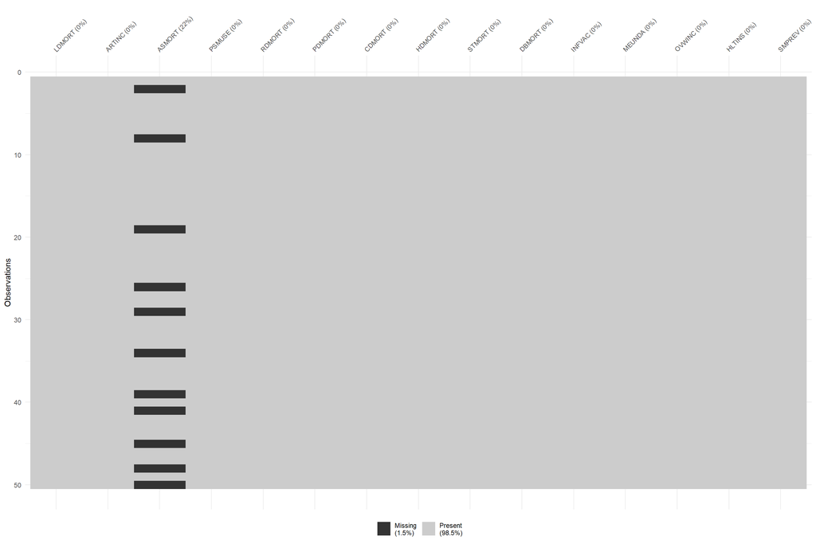

```r
visdat::vis_miss(DQA.Descriptors.Numeric, sort_miss = FALSE)
```

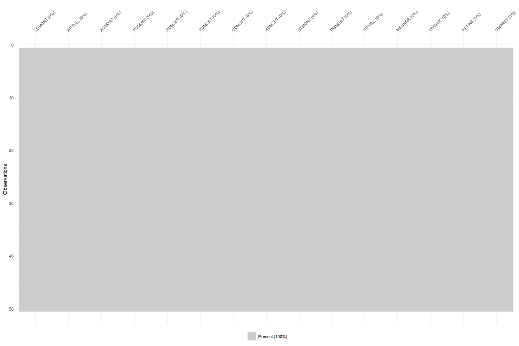

```r
##################################
# Conducting missing data imputation
# using Multivariate Imputation by Chained Equations
##################################
MICE_Model <- mice(DQA.Descriptors.Numeric, method='pmm', seed = 123)
DQA.Descriptors.Numeric <- complete(MICE_Model)

##################################
# Visualizing the missing data patterns
# after imputation
##################################
visdat::vis_miss(DQA.Descriptors.Numeric, sort_miss = FALSE)
```

#### 1.3.3.2 Outlier Detection

**[A]** Minimal outliers noted for 7 out of the 15 descriptors. Descriptor values were visualized through a boxplot including observations classified as suspected outliers using the IQR criterion. The IQR criterion means that all observations above the (75th percentile + 1.5 x IQR) or below the (25th percentile - 1.5 x IQR) are suspected outliers, where IQR is the difference between the third quartile (75th percentile) and first quartile (25th percentile).  
**[A.1]** LDMORT = 1  
**[A.2]** ARTINC = 4  
**[A.3]** RDMORT = 2  
**[A.5]** PDMORT = 1  
**[A.7]** DBMORT = 1  
**[A.9]** HLTINS = 1  
**[A.10]** SMPREV = 1

**Code Chunk | Output**

```r
##################################
# Loading dataset
##################################
DPA <- DQA.Descriptors.Numeric

##################################
# Gathering descriptive statistics
##################################
(DPA_Skimmed <- skim(DPA))
```

Data summary

| Name | DPA |
| --- | --- |
| Number of rows | 50 |
| Number of columns | 15 |
| _______________________ |  |
| Column type frequency: |  |
| numeric | 15 |
| ________________________ |  |
| Group variables | None |

**Variable type: numeric**

| skim_variable | n_missing | complete_rate | mean | sd | p0 | p25 | p50 | p75 | p100 | hist |
| --- | --- | --- | --- | --- | --- | --- | --- | --- | --- | --- |
| LDMORT | 0 | 1 | 10.54 | 2.82 | 6.8 | 8.70 | 10.20 | 11.95 | 22.5 | ▇▇▂▁▁ |
| ARTINC | 0 | 1 | 24.78 | 3.29 | 19.0 | 23.13 | 24.15 | 25.98 | 35.9 | ▃▇▃▁▁ |
| ASMORT | 0 | 1 | 11.05 | 2.48 | 7.5 | 8.70 | 10.90 | 12.90 | 16.7 | ▇▆▆▅▁ |
| PSMUSE | 0 | 1 | 82.59 | 3.09 | 76.2 | 80.53 | 82.70 | 85.33 | 87.9 | ▃▃▇▆▅ |
| RDMORT | 0 | 1 | 55.54 | 9.27 | 37.3 | 49.30 | 54.90 | 59.98 | 78.5 | ▂▇▇▃▁ |
| PDMORT | 0 | 1 | 119.99 | 27.81 | 43.9 | 102.33 | 119.85 | 139.60 | 177.7 | ▁▃▇▇▂ |
| CDMORT | 0 | 1 | 219.97 | 33.08 | 164.7 | 195.15 | 208.75 | 242.10 | 300.5 | ▃▇▅▂▂ |
| HDMORT | 0 | 1 | 166.95 | 27.69 | 116.5 | 147.83 | 158.05 | 182.30 | 229.9 | ▃▇▅▃▂ |
| STMORT | 0 | 1 | 36.86 | 5.77 | 25.6 | 33.50 | 36.75 | 41.45 | 48.8 | ▃▇▇▅▃ |
| DBMORT | 0 | 1 | 67.37 | 14.99 | 42.3 | 57.05 | 64.85 | 75.55 | 117.2 | ▆▇▅▂▁ |
| INFVAC | 0 | 1 | 39.01 | 3.94 | 29.0 | 35.88 | 39.20 | 42.03 | 49.0 | ▂▆▇▇▁ |
| MEUNDA | 0 | 1 | 3.69 | 0.53 | 2.8 | 3.32 | 3.70 | 4.00 | 4.9 | ▆▆▇▅▂ |
| OVWINC | 0 | 1 | 64.54 | 3.20 | 57.2 | 62.60 | 65.10 | 66.75 | 70.8 | ▃▃▇▇▃ |
| HLTINS | 0 | 1 | 15.84 | 4.73 | 5.4 | 12.55 | 15.70 | 18.32 | 29.1 | ▂▇▇▃▁ |
| SMPREV | 0 | 1 | 19.02 | 3.68 | 9.5 | 16.62 | 18.90 | 21.25 | 28.2 | ▁▆▇▅▂ |

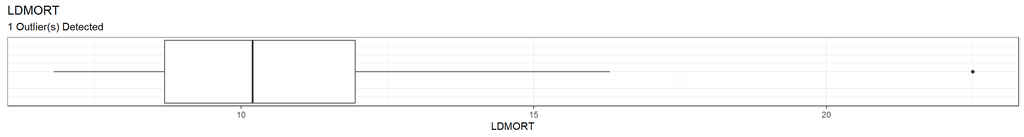

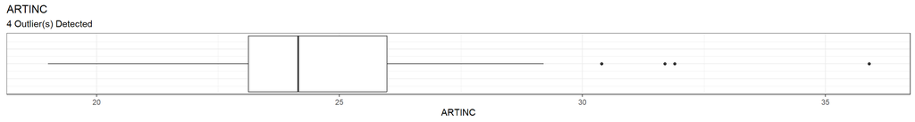

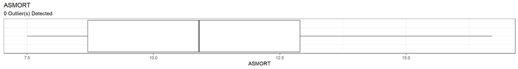

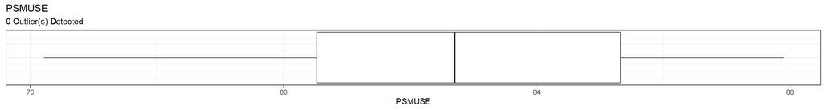

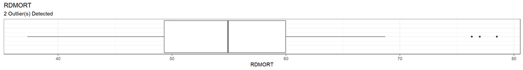

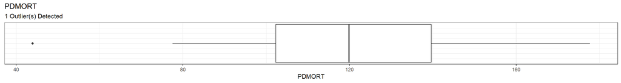

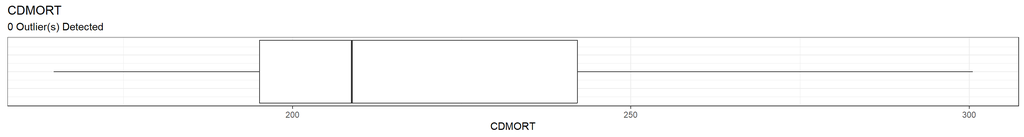

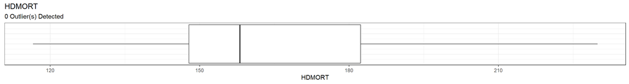

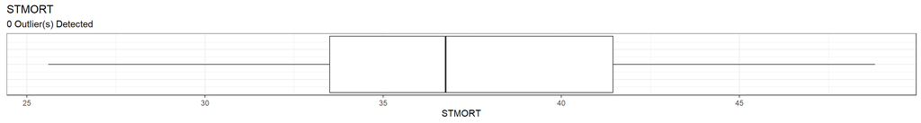

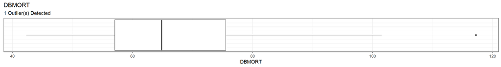

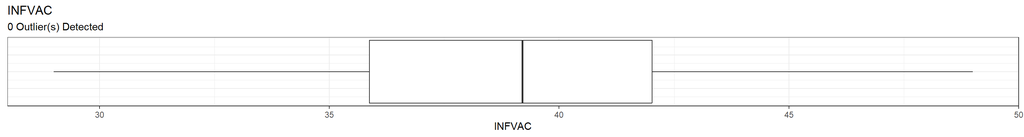

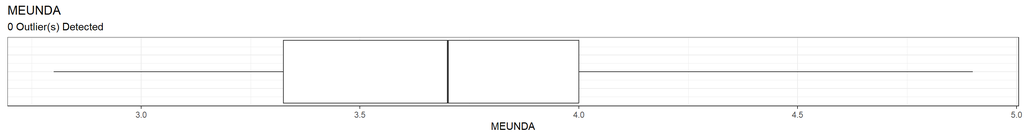

[3 more figures not shown]

```r
##################################
# Outlier Detection
##################################

##################################
# Listing all Descriptors
##################################
DPA.Descriptors <- DPA

##################################
# Listing all numeric Descriptors
##################################
DPA.Descriptors.Numeric <- DPA.Descriptors[,sapply(DPA.Descriptors, is.numeric)]

##################################
# Identifying outliers for the numeric Descriptors
##################################
OutlierCountList <- c()

for (i in 1:ncol(DPA.Descriptors.Numeric)) {
  Outliers <- boxplot.stats(DPA.Descriptors.Numeric[,i])$out
  OutlierCount <- length(Outliers)
  OutlierCountList <- append(OutlierCountList,OutlierCount)
  OutlierIndices <- which(DPA.Descriptors.Numeric[,i] %in% c(Outliers))
  print(
  ggplot(DPA.Descriptors.Numeric, aes(x=DPA.Descriptors.Numeric[,i])) +
  geom_boxplot() +
  theme_bw() +
  theme(axis.text.y=element_blank(),
        axis.ticks.y=element_blank()) +
  xlab(names(DPA.Descriptors.Numeric)[i]) +
  labs(title=names(DPA.Descriptors.Numeric)[i],
       subtitle=paste0(OutlierCount, " Outlier(s) Detected")))
}
```

#### 1.3.3.3 Zero and Near-Zero Variance

**[A]** No low variance observed for any descriptor in the dataset.

**Code Chunk | Output**

```r
##################################
# Zero and Near-Zero Variance
##################################

##################################
# Identifying columns with low variance
###################################
DPA_LowVariance <- nearZeroVar(DPA,
                               freqCut = 80/20,
                               uniqueCut = 10,
                               saveMetrics= TRUE)
(DPA_LowVariance[DPA_LowVariance$nzv,])
```

```
## [1] freqRatio     percentUnique zeroVar       nzv
## <0 rows> (or 0-length row.names)
```

```r
if ((nrow(DPA_LowVariance[DPA_LowVariance$nzv,]))==0){

  print("No low variance descriptors noted.")

} else {

  print(paste0("Low variance observed for ",
               (nrow(DPA_LowVariance[DPA_LowVariance$nzv,])),
               " numeric variable(s) with First.Second.Mode.Ratio>4 and Unique.Count.Ratio<0.10."))

  DPA_LowVarianceForRemoval <- (nrow(DPA_LowVariance[DPA_LowVariance$nzv,]))

  print(paste0("Low variance can be resolved by removing ",
               (nrow(DPA_LowVariance[DPA_LowVariance$nzv,])),
               " numeric variable(s)."))

  for (j in 1:DPA_LowVarianceForRemoval) {
  DPA_LowVarianceRemovedVariable <- rownames(DPA_LowVariance[DPA_LowVariance$nzv,])[j]
  print(paste0("Variable ",
               j,
               " for removal: ",
               DPA_LowVarianceRemovedVariable))
  }

  DPA %>%
  skim() %>%
  dplyr::filter(skim_variable %in% rownames(DPA_LowVariance[DPA_LowVariance$nzv,]))

}
```

```
## [1] "No low variance descriptors noted."
```

#### 1.3.3.4 Collinearity

**[A]** High multicollinearity with Pearson correlation coefficients >90% was noted in a pair of descriptors in the dataset.  
**[A.1]** HDMORT and CDMORT = 0.99  
**[A.2]** CDMORT was removed based on its higher correlation with other descriptors.

**Code Chunk | Output**

```r
##################################
# Measuring pairwise correlation between descriptors
##################################
(DPA_Correlation <- cor(DPA.Descriptors.Numeric,
                        method = "pearson",
                        use="pairwise.complete.obs"))
```

```
##             LDMORT       ARTINC       ASMORT       PSMUSE      RDMORT
## LDMORT  1.00000000  0.173093335 -0.232025288 -0.345100550  0.02923731
## ARTINC  0.17309333  1.000000000 -0.042746459  0.024546154  0.60290597
## ASMORT -0.23202529 -0.042746459  1.000000000 -0.087053707  0.02466696
## PSMUSE -0.34510055  0.024546154 -0.087053707  1.000000000 -0.11152216
## RDMORT  0.02923731  0.602905967  0.024666956 -0.111522163  1.00000000
## PDMORT  0.45267604  0.662922162 -0.210484947 -0.286784690  0.50529506
## CDMORT  0.07404928  0.667228833  0.023618891 -0.214153256  0.58858032
## HDMORT  0.04934776  0.636548347 -0.001775156 -0.206862030  0.52444923
## STMORT  0.17126776  0.582853439  0.066770232 -0.219881708  0.70019055
## DBMORT  0.17609150  0.481600436  0.191885492 -0.124643846  0.61452185
## INFVAC -0.10505851  0.103088137  0.100706735  0.399251809  0.24772090
## MEUNDA  0.22133327  0.803258627 -0.017665903  0.009246146  0.41867094
## OVWINC  0.16735471  0.498314042  0.149667042 -0.217877006  0.63784116
## HLTINS  0.37829219  0.002972526 -0.108605067 -0.488950184  0.12993910
## SMPREV  0.23811659  0.823678167 -0.099197602 -0.055348594  0.59858835
##             PDMORT      CDMORT       HDMORT      STMORT      DBMORT      INFVAC
## LDMORT  0.45267604  0.07404928  0.049347761  0.17126776  0.17609150 -0.10505851
## ARTINC  0.66292216  0.66722883  0.636548347  0.58285344  0.48160044  0.10308814
## ASMORT -0.21048495  0.02361889 -0.001775156  0.06677023  0.19188549  0.10070674
## PSMUSE -0.28678469 -0.21415326 -0.206862030 -0.21988171 -0.12464385  0.39925181
## RDMORT  0.50529506  0.58858032  0.524449231  0.70019055  0.61452185  0.24772090
## PDMORT  1.00000000  0.61855185  0.581638625  0.56453130  0.51296109 -0.05135669
## CDMORT  0.61855185  1.00000000  0.986330154  0.79569366  0.46503091 -0.09852403
## HDMORT  0.58163863  0.98633015  1.000000000  0.69775225  0.41225978 -0.11351086
## STMORT  0.56453130  0.79569366  0.697752254  1.00000000  0.50413319  0.02353408
## DBMORT  0.51296109  0.46503091  0.412259779  0.50413319  1.00000000  0.24952376
## INFVAC -0.05135669 -0.09852403 -0.113510863  0.02353408  0.24952376  1.00000000
## MEUNDA  0.48590617  0.64341929  0.640170352  0.49206776  0.35231401 -0.17366823
## OVWINC  0.60733512  0.67870794  0.621196381  0.68784352  0.49793894 -0.06691508
## HLTINS  0.36864746  0.41605763  0.378207992  0.45854866  0.01034802 -0.51094161
## SMPREV  0.73851432  0.66017408  0.630688330  0.59808334  0.49613487  0.06481756
##              MEUNDA      OVWINC       HLTINS      SMPREV
## LDMORT  0.221333267  0.16735471  0.378292185  0.23811659
## ARTINC  0.803258627  0.49831404  0.002972526  0.82367817
## ASMORT -0.017665903  0.14966704 -0.108605067 -0.09919760
## PSMUSE  0.009246146 -0.21787701 -0.488950184 -0.05534859
## RDMORT  0.418670943  0.63784116  0.129939097  0.59858835
## PDMORT  0.485906174  0.60733512  0.368647458  0.73851432
## CDMORT  0.643419286  0.67870794  0.416057632  0.66017408
## HDMORT  0.640170352  0.62119638  0.378207992  0.63068833
## STMORT  0.492067763  0.68784352  0.458548660  0.59808334
## DBMORT  0.352314013  0.49793894  0.010348016  0.49613487
## INFVAC -0.173668230 -0.06691508 -0.510941607  0.06481756
## MEUNDA  1.000000000  0.27967009  0.152816174  0.60964853
## OVWINC  0.279670088  1.00000000  0.378877840  0.67261164
## HLTINS  0.152816174  0.37887784  1.000000000  0.13686509
## SMPREV  0.609648533  0.67261164  0.136865092  1.00000000
```

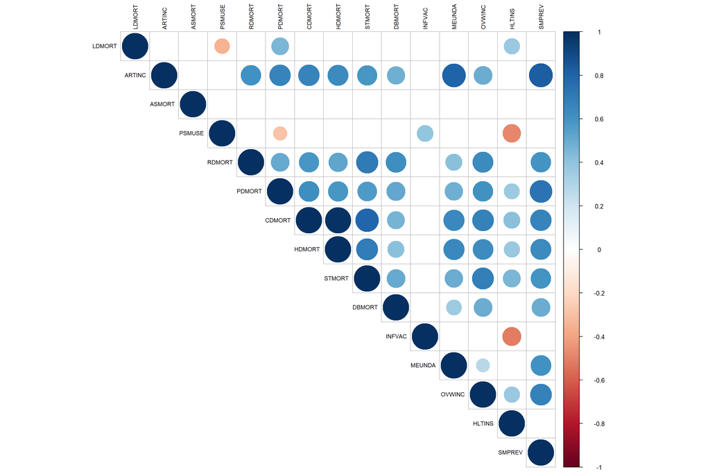

```r
##################################
# Testing pairwise correlation between descriptors
##################################
DPA_CorrelationTest <- cor.mtest(DPA.Descriptors.Numeric,
                       method = "pearson",
                       conf.level = 0.95)

##################################
# Visualizing pairwise correlation between descriptors
##################################
corrplot(cor(DPA.Descriptors.Numeric,
             method = "pearson",
             use="pairwise.complete.obs"),
             method = "circle",
             type = "upper",
             order = "original",
             tl.col = "black",
             tl.cex = 0.75,
             tl.srt = 90,
             sig.level = 0.05,
             p.mat = DPA_CorrelationTest$p,
             insig = "blank")
```

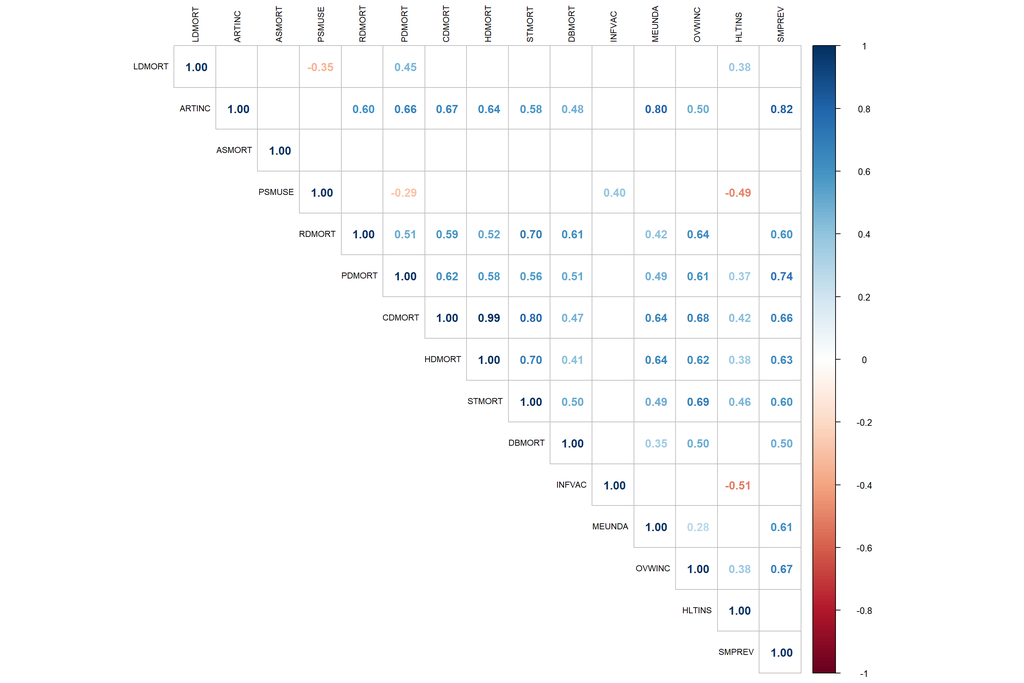

```r
corrplot(cor(DPA.Descriptors.Numeric,
             method = "pearson",
             use="pairwise.complete.obs"),
             method = "number",
             type = "upper",
             order = "original",
             tl.col = "black",
             tl.cex = 0.75,
             tl.srt = 90,
             sig.level = 0.05,
             p.mat = DPA_CorrelationTest$p,
             insig = "blank")
```

```r
##################################
# Identifying the highly correlated variables
##################################
(DPA_HighlyCorrelatedCount <- sum(abs(DPA_Correlation[upper.tri(DPA_Correlation)])>0.90))
```

```
## [1] 1
```

```r
if (DPA_HighlyCorrelatedCount > 0) {
  DPA_HighlyCorrelated <- findCorrelation(DPA_Correlation, cutoff = 0.90)

  (DPA_HighlyCorrelatedForRemoval <- length(DPA_HighlyCorrelated))

  print(paste0("High correlation can be resolved by removing ",
               (DPA_HighlyCorrelatedForRemoval),
               " numeric variable(s)."))

  for (j in 1:DPA_HighlyCorrelatedForRemoval) {
    DPA_HighlyCorrelatedRemovedVariable <- colnames(DPA.Descriptors.Numeric)[DPA_HighlyCorrelated[j]]
    print(paste0("Variable ",
                 j,
                 " for removal: ",
                 DPA_HighlyCorrelatedRemovedVariable))
  }

}
```

```
## [1] "High correlation can be resolved by removing 1 numeric variable(s)."
## [1] "Variable 1 for removal: CDMORT"
```

```
## [1] "High correlation observed for 1 pairs of numeric variable(s) with Correlation.Coefficient>0.90."
```

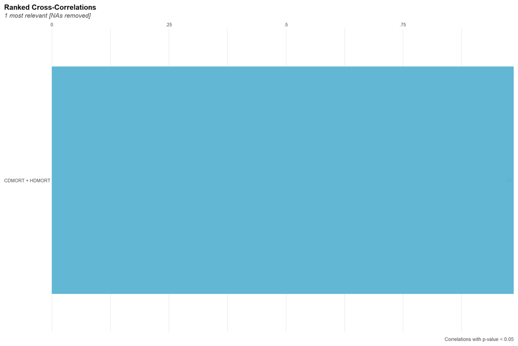

```r
if (DPA_HighlyCorrelatedCount == 0) {
  print("No highly correlated predictors noted.")
} else {
  print(paste0("High correlation observed for ",
               (DPA_HighlyCorrelatedCount),
               " pairs of numeric variable(s) with Correlation.Coefficient>0.90."))

  (DPA_HighlyCorrelatedPairs <- corr_cross(DPA.Descriptors.Numeric,
  max_pvalue = 0.05,
  top = DPA_HighlyCorrelatedCount,
  rm.na = TRUE,
  grid = FALSE
))

}
```

```r
##################################
# Removing individual descriptors
# among the highly correlated pair
##################################
DPA.Descriptors.Numeric <- DPA.Descriptors.Numeric[,!colnames(DPA.Descriptors.Numeric) %in% c("CDMORT")]
```

#### 1.3.3.5 Linear Dependencies

**[A]** No linear dependencies observed for any subset of decriptors in the dataset.

**Code Chunk | Output**

```r
##################################
# Linear Dependencies
##################################

##################################
# Finding linear dependencies
##################################
DPA_LinearlyDependent <- findLinearCombos(DPA.Descriptors.Numeric)

##################################
# Identifying the linearly dependent variables
##################################
DPA_LinearlyDependent <- findLinearCombos(DPA.Descriptors.Numeric)

(DPA_LinearlyDependentCount <- length(DPA_LinearlyDependent$linearCombos))
```

```
## [1] 0
```

```r
if (DPA_LinearlyDependentCount == 0) {
  print("No linearly dependent predictors noted.")
} else {
  print(paste0("Linear dependency observed for ",
               (DPA_LinearlyDependentCount),
               " subset(s) of numeric variable(s)."))

  for (i in 1:DPA_LinearlyDependentCount) {
    DPA_LinearlyDependentSubset <- colnames(DPA.Descriptors.Numeric)[DPA_LinearlyDependent$linearCombos[[i]]]
    print(paste0("Linear dependent variable(s) for subset ",
                 i,
                 " include: ",
                 DPA_LinearlyDependentSubset))
  }

}
```

```
## [1] "No linearly dependent predictors noted."
```

```r
##################################
# Identifying the linearly dependent variables for removal
##################################

if (DPA_LinearlyDependentCount > 0) {
  DPA_LinearlyDependent <- findLinearCombos(DPA.Descriptors.Numeric)

  DPA_LinearlyDependentForRemoval <- length(DPA_LinearlyDependent$remove)

  print(paste0("Linear dependency can be resolved by removing ",
               (DPA_LinearlyDependentForRemoval),
               " numeric variable(s)."))

  for (j in 1:DPA_LinearlyDependentForRemoval) {
  DPA_LinearlyDependentRemovedVariable <- colnames(DPA.Descriptors.Numeric)[DPA_LinearlyDependent$remove[j]]
  print(paste0("Variable ",
               j,
               " for removal: ",
               DPA_LinearlyDependentRemovedVariable))
  }

}
```

#### 1.3.3.6 Distributional Shape

**[A]** No shape transformation was necessary as the distributional skewness observed among individual descriptors was normal (all values within +3 and -3) with minimal outliers.

**Code Chunk | Output**

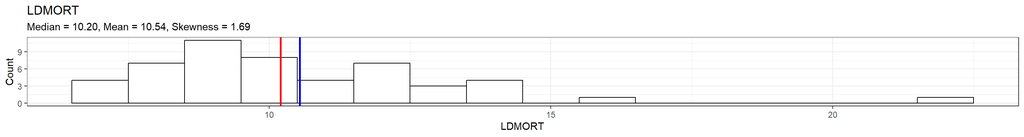

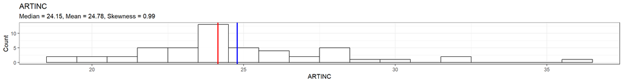

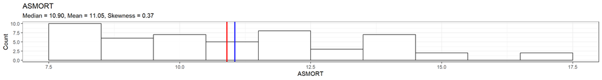

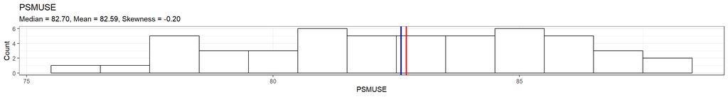

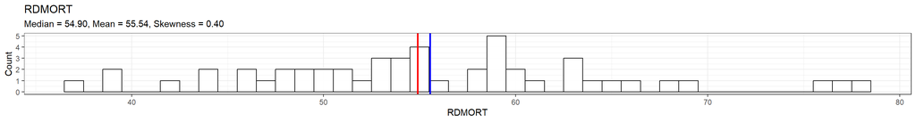

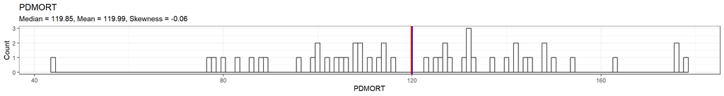

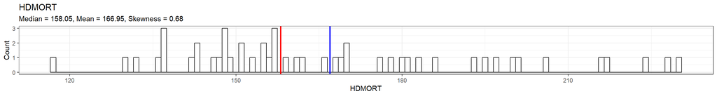

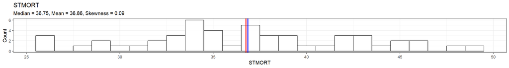

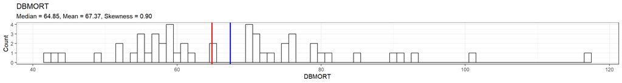

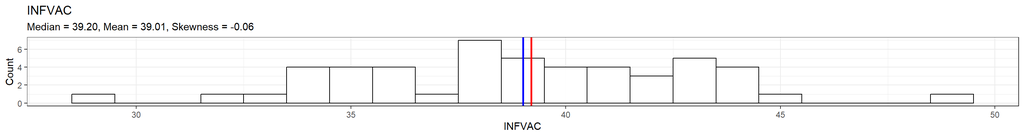

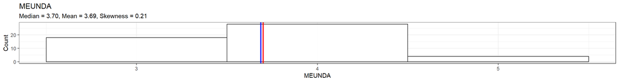

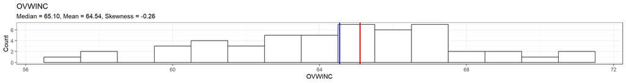

[2 more figures not shown]

```r
##################################
# Distributional Shape
##################################

##################################
# Formulating the histogram
# for the numeric descriptors
##################################
for (i in 1:ncol(DPA.Descriptors.Numeric)) {
  Median <- format(round(median(DPA.Descriptors.Numeric[,i],na.rm = TRUE),2), nsmall=2)
  Mean <- format(round(mean(DPA.Descriptors.Numeric[,i],na.rm = TRUE),2), nsmall=2)
  Skewness <- format(round(skewness(DPA.Descriptors.Numeric[,i],na.rm = TRUE),2), nsmall=2)
  print(
  ggplot(DPA.Descriptors.Numeric, aes(x=DPA.Descriptors.Numeric[,i])) +
  geom_histogram(binwidth=1,color="black", fill="white") +
  geom_vline(aes(xintercept=mean(DPA.Descriptors.Numeric[,i])),
            color="blue", size=1) +
    geom_vline(aes(xintercept=median(DPA.Descriptors.Numeric[,i])),
            color="red", size=1) +
  theme_bw() +
  ylab("Count") +
  xlab(names(DPA.Descriptors.Numeric)[i]) +
  labs(title=names(DPA.Descriptors.Numeric)[i],
       subtitle=paste0("Median = ", Median,
                       ", Mean = ", Mean,
                       ", Skewness = ", Skewness)))
}
```

#### 1.3.3.7 Data Normalization

**[A]** Z-score normalization was applied to generate a transformed data with a distributional mean of zero and a standard deviation equal to one - allowing a consistent scale among the descriptors.

**Code Chunk | Output**

```r
##################################
# Data Normalization
##################################

DPA.Descriptors.Numeric.CenteredScaled <- preProcess(DPA.Descriptors.Numeric, method = c("center","scale"))
DPA.Descriptors.Numeric <- predict(DPA.Descriptors.Numeric.CenteredScaled, DPA.Descriptors.Numeric)
```

### 1.3.4 Data Pre-Assessment

#### 1.3.4.1 Correlation Matrix Assessment - Kaiser-Meyer-Olkin Factor Adequacy

**Code Chunk | Output**

```r
##################################
# Calculating the Kaiser-Meyer-Olkin Factor Adequacy
##################################
(DPA_KMOFactorAdequacy <- KMO(DPA.Descriptors.Numeric))
```

```
##
## -- Kaiser-Meyer-Olkin criterion (KMO) ------------------------------------------
##
## ! The overall KMO value for your data is mediocre.
##   These data are probably suitable for factor analysis.
##
##   Overall: 0.679
##
##   For each variable:
## LDMORT ARTINC ASMORT PSMUSE RDMORT PDMORT HDMORT STMORT DBMORT INFVAC MEUNDA
##  0.359  0.800  0.152  0.391  0.716  0.873  0.721  0.891  0.849  0.284  0.547
## OVWINC HLTINS SMPREV
##  0.645  0.670  0.900
```

```r
##################################
# Removing individual descriptors
# with low KMO values
##################################
DPA.Descriptors.Numeric <- DPA.Descriptors.Numeric[,!colnames(DPA.Descriptors.Numeric) %in% c("ASMORT")]

##################################
# Calculating the Kaiser-Meyer-Olkin Factor Adequacy
##################################
(DPA_KMOFactorAdequacy <- KMO(DPA.Descriptors.Numeric))
```

```
##
## -- Kaiser-Meyer-Olkin criterion (KMO) ------------------------------------------
##
## v The overall KMO value for your data is middling.
##   These data are probably suitable for factor analysis.
##
##   Overall: 0.752
##
##   For each variable:
## LDMORT ARTINC PSMUSE RDMORT PDMORT HDMORT STMORT DBMORT INFVAC MEUNDA OVWINC
##  0.434  0.790  0.546  0.832  0.855  0.785  0.882  0.851  0.350  0.603  0.763
## HLTINS SMPREV
##  0.655  0.906
```

```r
##################################
# Removing individual descriptors
# with low KMO values
##################################
DPA.Descriptors.Numeric <- DPA.Descriptors.Numeric[,!colnames(DPA.Descriptors.Numeric) %in% c("INFVAC")]

##################################
# Calculating the Kaiser-Meyer-Olkin Factor Adequacy
##################################
(DPA_KMOFactorAdequacy <- KMO(DPA.Descriptors.Numeric))
```

```
##
## -- Kaiser-Meyer-Olkin criterion (KMO) ------------------------------------------
##
## v The overall KMO value for your data is meritorious.
##   These data are probably suitable for factor analysis.
##
##   Overall: 0.81
##
##   For each variable:
## LDMORT ARTINC PSMUSE RDMORT PDMORT HDMORT STMORT DBMORT MEUNDA OVWINC HLTINS
##  0.587  0.780  0.738  0.880  0.851  0.841  0.875  0.840  0.703  0.854  0.562
## SMPREV
##  0.900
```

```r
##################################
# Removing individual descriptors
# with low KMO values
##################################
DPA.Descriptors.Numeric <- DPA.Descriptors.Numeric[,!colnames(DPA.Descriptors.Numeric) %in% c("HLTINS")]

##################################
# Calculating the Kaiser-Meyer-Olkin Factor Adequacy
##################################
(DPA_KMOFactorAdequacy <- KMO(DPA.Descriptors.Numeric))
```

```
##
## -- Kaiser-Meyer-Olkin criterion (KMO) ------------------------------------------
##
## v The overall KMO value for your data is meritorious.
##   These data are probably suitable for factor analysis.
##
##   Overall: 0.832
##
##   For each variable:
## LDMORT ARTINC PSMUSE RDMORT PDMORT HDMORT STMORT DBMORT MEUNDA OVWINC SMPREV
##  0.469  0.822  0.645  0.865  0.878  0.805  0.902  0.927  0.734  0.857  0.885
```

```r
##################################
# Removing individual descriptors
# with low KMO values
##################################
DPA.Descriptors.Numeric <- DPA.Descriptors.Numeric[,!colnames(DPA.Descriptors.Numeric) %in% c("LDMORT")]

##################################
# Calculating the Kaiser-Meyer-Olkin Factor Adequacy
##################################
(DPA_KMOFactorAdequacy <- KMO(DPA.Descriptors.Numeric))
```

```
##
## -- Kaiser-Meyer-Olkin criterion (KMO) ------------------------------------------
##
## v The overall KMO value for your data is meritorious.
##   These data are probably suitable for factor analysis.
##
##   Overall: 0.866
##
##   For each variable:
## ARTINC PSMUSE RDMORT PDMORT HDMORT STMORT DBMORT MEUNDA OVWINC SMPREV
##  0.828  0.589  0.880  0.901  0.892  0.908  0.921  0.785  0.857  0.878
```

```r
##################################
# Removing individual descriptors
# with low KMO values
##################################
DPA.Descriptors.Numeric <- DPA.Descriptors.Numeric[,!colnames(DPA.Descriptors.Numeric) %in% c("PSMUSE")]

##################################
# Calculating the Kaiser-Meyer-Olkin Factor Adequacy
##################################
(DPA_KMOFactorAdequacy <- KMO(DPA.Descriptors.Numeric))
```

```
##
## -- Kaiser-Meyer-Olkin criterion (KMO) ------------------------------------------
##
## v The overall KMO value for your data is meritorious.
##   These data are probably suitable for factor analysis.
##
##   Overall: 0.871
##
##   For each variable:
## ARTINC RDMORT PDMORT HDMORT STMORT DBMORT MEUNDA OVWINC SMPREV
##  0.828  0.879  0.935  0.888  0.904  0.919  0.782  0.853  0.876
```

#### 1.3.4.2 Correlation Matrix Assessment - Bartlett’s Test of Sphericity

**[A]** The computed p-value from the Bartlett’s Test of Sphericity was statistically significant (<0.00001), rejecting the null hypothesis that the correlation matrix is an identity matrix (ones on the diagonal and zeros on the off-diagonal). Results indicated that there is enough evidence to support the existence of underlying factors, suggesting that the correlation matrix is appropriate for exploratory factor analysis.

**Code Chunk | Output**

```r
##################################
# Calculating the Bartlett's Test of Sphericity
##################################
(DPA_BartlettTest <- cortest.bartlett(DPA.Descriptors.Numeric,
                                      n=nrow(DPA.Descriptors.Numeric)))
```

```
## $chisq
## [1] 321.9186
##
## $p.value
## [1] 1.28086e-47
##
## $df
## [1] 36
```

#### 1.3.4.3 Correlation Matrix Assessment - Covariance Validity

**[A]** Covariance among descriptors in the correlation matrix was sufficient to justify the conduct of an exploratory factor analysis. 97% (35/36) of the pairwise associations using the Pearson correlation coefficient were above 30%.

**Code Chunk | Output**

```r
##################################
# Measuring pairwise correlation between descriptors
##################################
(DPA_Correlation <- cor(DPA.Descriptors.Numeric,
                        method = "pearson",
                        use="pairwise.complete.obs"))
```

```
##           ARTINC    RDMORT    PDMORT    HDMORT    STMORT    DBMORT    MEUNDA
## ARTINC 1.0000000 0.6029060 0.6629222 0.6365483 0.5828534 0.4816004 0.8032586
## RDMORT 0.6029060 1.0000000 0.5052951 0.5244492 0.7001906 0.6145218 0.4186709
## PDMORT 0.6629222 0.5052951 1.0000000 0.5816386 0.5645313 0.5129611 0.4859062
## HDMORT 0.6365483 0.5244492 0.5816386 1.0000000 0.6977523 0.4122598 0.6401704
## STMORT 0.5828534 0.7001906 0.5645313 0.6977523 1.0000000 0.5041332 0.4920678
## DBMORT 0.4816004 0.6145218 0.5129611 0.4122598 0.5041332 1.0000000 0.3523140
## MEUNDA 0.8032586 0.4186709 0.4859062 0.6401704 0.4920678 0.3523140 1.0000000
## OVWINC 0.4983140 0.6378412 0.6073351 0.6211964 0.6878435 0.4979389 0.2796701
## SMPREV 0.8236782 0.5985883 0.7385143 0.6306883 0.5980833 0.4961349 0.6096485
##           OVWINC    SMPREV
## ARTINC 0.4983140 0.8236782
## RDMORT 0.6378412 0.5985883
## PDMORT 0.6073351 0.7385143
## HDMORT 0.6211964 0.6306883
## STMORT 0.6878435 0.5980833
## DBMORT 0.4979389 0.4961349
## MEUNDA 0.2796701 0.6096485
## OVWINC 1.0000000 0.6726116
## SMPREV 0.6726116 1.0000000
```

```r
##################################
# Identifying the minimally correlated variables
##################################
(DPA_MinimallyCorrelatedCount <- sum(abs(DPA_Correlation[upper.tri(DPA_Correlation)])>0.30))
```

```
## [1] 35
```

```r
(DPA_AllPairs <- length(DPA.Descriptors.Numeric)*(length(DPA.Descriptors.Numeric)-1)/2)
```

```
## [1] 36
```

```r
(DPA_MinimallyCorrelatedCountPercentage <- DPA_MinimallyCorrelatedCount/DPA_AllPairs)
```

```
## [1] 0.9722222
```

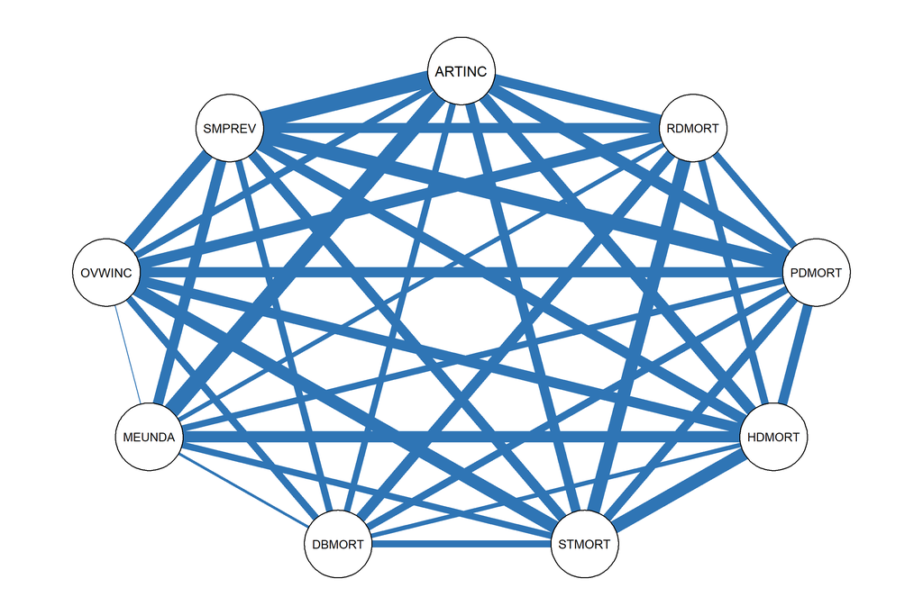

```r
qgraph(cor(DPA.Descriptors.Numeric),
       cut=0.30,
       details=FALSE,
       posCol="#2F75B5",
       negCol="#FF5050",
       labels=names(DPA.Descriptors.Numeric))
```

#### 1.3.4.4 Correlation Matrix Assessment - Determinant Computation

**[A]** The determinant of the correlation matrix was computed as 0.00080 which was greater than 0.00001 indicating the absence of the likelihood for a multicollinearity problem. The results allowed for matrix operations to produce stable results during exploratory factor analysis.

**Code Chunk | Output**

```r
##################################
# Computing the determinant of the correlation matrix
##################################
(DPA_CorrelationMatrixDeterminant <- det(cor(DPA.Descriptors.Numeric)))
```

```
## [1] 0.0008028455
```

#### 1.3.4.5 Pre-Processed Dataset

**[A]** The pre-processed tabular dataset was comprised of 50 observations and 9 descriptor variables.  
**[A.1]** 50 rows (observations)  
**[A.2]** 9 columns (descriptors)  
**[A.2.1]** PDMORT  
**[A.2.2]** DBMORT  
**[A.2.3]** STMORT  
**[A.2.4]** HDMORT  
**[A.2.5]** RDMORT  
**[A.2.6]** SMPREV  
**[A.2.7]** OVWINC  
**[A.2.8]** ARTINC  
**[A.2.9]** MEUNDA

**Code Chunk | Output**

```r
##################################
# Gathering descriptive statistics
##################################
(DPA_Skimmed <- skim(DPA.Descriptors.Numeric))
```

Data summary

| Name | DPA.Descriptors.Numeric |
| --- | --- |
| Number of rows | 50 |
| Number of columns | 9 |
| _______________________ |  |
| Column type frequency: |  |
| numeric | 9 |
| ________________________ |  |
| Group variables | None |

**Variable type: numeric**

| skim_variable | n_missing | complete_rate | mean | sd | p0 | p25 | p50 | p75 | p100 | hist |
| --- | --- | --- | --- | --- | --- | --- | --- | --- | --- | --- |
| ARTINC | 0 | 1 | 0 | 1 | -1.76 | -0.50 | -0.19 | 0.36 | 3.38 | ▃▇▃▁▁ |
| RDMORT | 0 | 1 | 0 | 1 | -1.97 | -0.67 | -0.07 | 0.48 | 2.48 | ▂▇▇▃▁ |
| PDMORT | 0 | 1 | 0 | 1 | -2.74 | -0.64 | -0.01 | 0.71 | 2.08 | ▁▃▇▇▂ |
| HDMORT | 0 | 1 | 0 | 1 | -1.82 | -0.69 | -0.32 | 0.55 | 2.27 | ▃▇▅▃▂ |
| STMORT | 0 | 1 | 0 | 1 | -1.95 | -0.58 | -0.02 | 0.80 | 2.07 | ▃▇▇▅▃ |
| DBMORT | 0 | 1 | 0 | 1 | -1.67 | -0.69 | -0.17 | 0.55 | 3.32 | ▆▇▅▂▁ |
| MEUNDA | 0 | 1 | 0 | 1 | -1.66 | -0.68 | 0.03 | 0.59 | 2.28 | ▆▆▇▅▂ |
| OVWINC | 0 | 1 | 0 | 1 | -2.29 | -0.61 | 0.18 | 0.69 | 1.96 | ▃▃▇▇▃ |
| SMPREV | 0 | 1 | 0 | 1 | -2.59 | -0.65 | -0.03 | 0.61 | 2.50 | ▁▆▇▅▂ |

### 1.3.5 Data Exploration

#### 1.3.5.1 Correlation Matrix

**[A]** All pairwise correlations among descriptors were positive with values ranging from 0.28 to 0.82 .

**Code Chunk | Output**

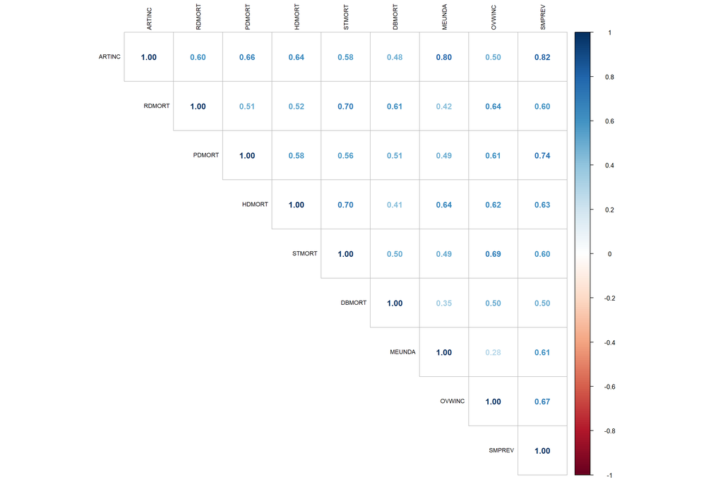

```r
##################################
# Testing pairwise correlation between descriptors
##################################
DPA_CorrelationTest <- cor.mtest(DPA.Descriptors.Numeric,
                       method = "pearson",
                       conf.level = 0.95)

##################################
# Plotting the pairwise association
# between descriptors
##################################
corrplot(cor(DPA.Descriptors.Numeric,
             method = "pearson",
             use="pairwise.complete.obs"),
             method = "number",
             type = "upper",
             order = "original",
             tl.col = "black",
             tl.cex = 0.75,
             tl.srt = 90,
             sig.level = 0.05,
             p.mat = DPA_CorrelationTest$p,
             insig = "blank")
```